# Homework 03

## 0.13 12. Bonus Learning Time: This is mostly just for learning some new things.

When you used str() to see how many levels of genhlth there were, you should have discovered the answer. But we can also do this another way, which is very useful as you will see. But first,

A. Use the levels() function on your genhlth variable to return the level names of genhlth **ANSWER:**

```r
levels(health$genhlth)
```

```
## [1] "excellent" "fair"      "good"      "poor"      "very good"
```

B. Use the nlevels() function on your genhlth variable to return the number of levels of genhlth **ANSWER:**

```r
nlevels(health$genhlth)
```

```
## [1] 5
```

C. We can use the histogram() function in the lattice library to create some nice graphs. In order to do so, you will have to leverage some of the function arguments that are not needed to create the default graph. For example, you could plot a histogram for weight as a function of gender (groups). But there are some special things we need to keep in mind.

- The ~ needs to precede the variable that you want to plot. There is good reason for this, but we won’t get into the reason why just yet.
- The | is used to specify which factor/categorical variable by which to split out your variable.
- So ~X | Race would mean “Hey, plot the numeric variable X for each level of Race.”

So, using our health data frame, let’s plot a histogram for weight a each level of gender, we would have:

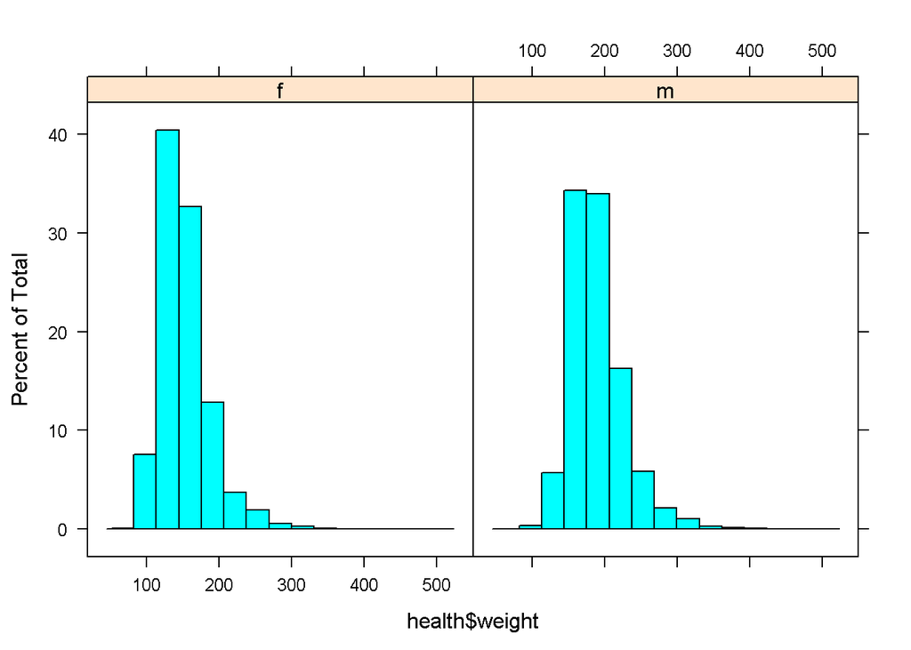

```r
histogram(~health$weight | health$gender)
```

D. What is the label on the y-axis? **ANSWER:** Percent of total scores, not frequencies.

By default, histogram() does not plot frequencies. Rather, the default plot type is “percent”. The code behind the default would look like. Also, notice that when you add an argument, you need to separate each argument with a comma. If you don’t include the comma, R with throw an error because you aren’t telling it what to do correctly.

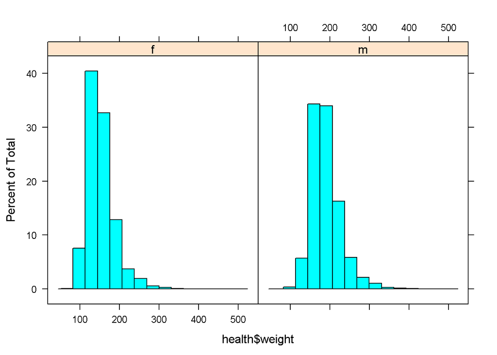

```r
histogram(~health$weight | health$gender, type = "percent")
```

E. We can change the type argument from “percent” to “count” by copying the code above and modifying it in the code block below. Remember, all arguments need to be inside the parentheses of the histogram() function; always make sure you enclose your functions in parentheses. **ANSWER:**

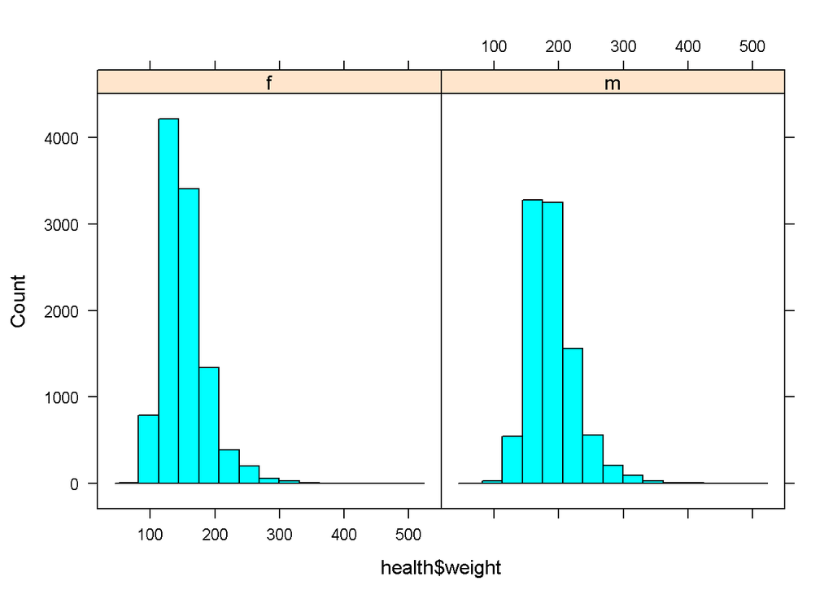

```r
histogram(~health$weight | health$gender, type = "count")
```

F. What is the label on the y-axis? **ANSWER:** Counts or frequency counts

Notice that the x-axis label on the graph looks clunky with the $ in the variable name. We can change it by adding the xlab argument to our code. We can add a main label too by adding the main arugument. The labels are letter strings, so strings need to be inside quotes. These are already added to the code, but you could change them if you wanted to. Again, notice that the arguments are separated by commas. Also, as shown, you can put arguments on separate lines if you wish to make your code more readable, but if you do, they lines need to be indented.

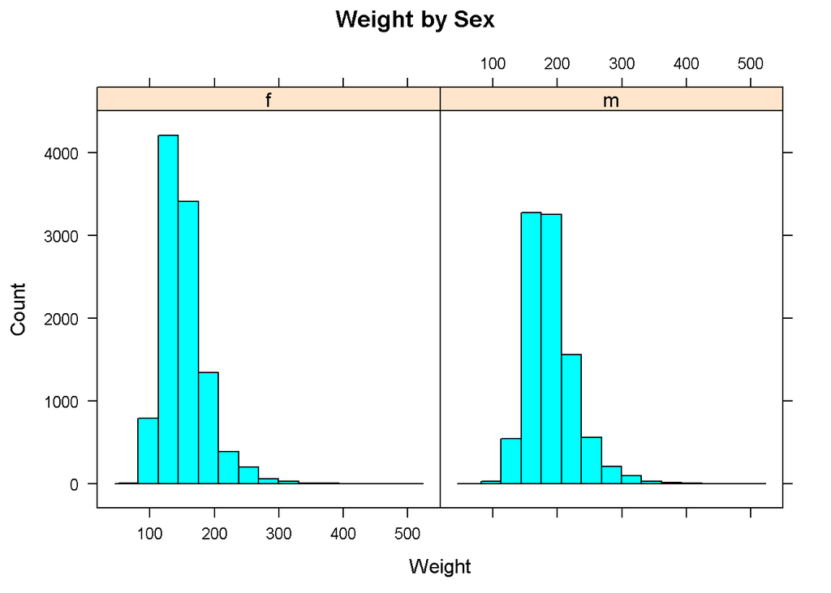

```r
histogram(~health$weight | health$gender, type = "count",
          main = "Weight by Sex",
          xlab = "Weight")
```

And if you don’t like the side-by-side layout, you can add the layout argument. However, you will need to know how many levels there are of your grouping variable. In this example, you would use the number of levels of sex, which is 2. By default, the layout displays the graphs side-by-side. I set layout = c(1,2) so that we can see both plots along the same x-axis with one on top of the other.

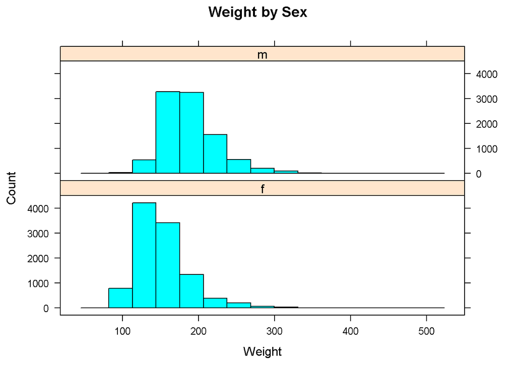

```r
histogram(~health$weight | health$gender, type = "count",
          main = "Weight by Sex",
          xlab = "Weight",
          layout = c(1, 2))
```

G. Based on your graph, do weights appear greater for men or for women? **ANSWER:** Greater for men. The male distribution is shifted further to the right (higher weights)

But if we wanted to plot the graphs in a similar way to see groups based on the genhlth variable rather than the sex variable, you would have to count the levels and change the from 2 to the other value. If you use the nlevels() function as demostrated above, you can replace 2 with nlevels(health$genhlth) and R will do this for you. Be careful, however, because you are nesting a functions inside of functions and you need to make sure your parentheses match. If you look carefully, you are nesting nlevels() inside c() which is inside histogram(), which gives you 3 sets of parentheses.

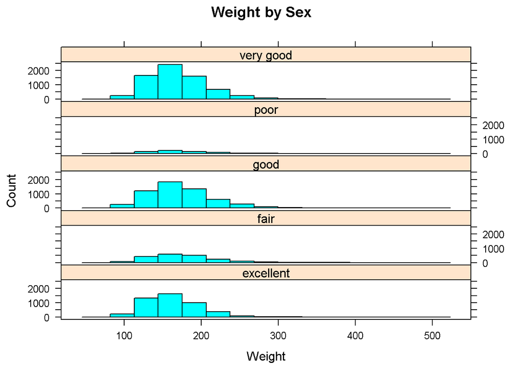

```r
histogram(~health$weight | health$genhlth, type = "count",
          main = "Weight by Sex",
          xlab = "Weight",
          layout = c(1, nlevels(health$genhlth)))
```

H. But this graph is (probably) not yet perfect because you (probably) didn’t change the labels to reflect your new grouping variable. Change main and xlab lables to be correct for the variables you are plotting. **ANSWER:**

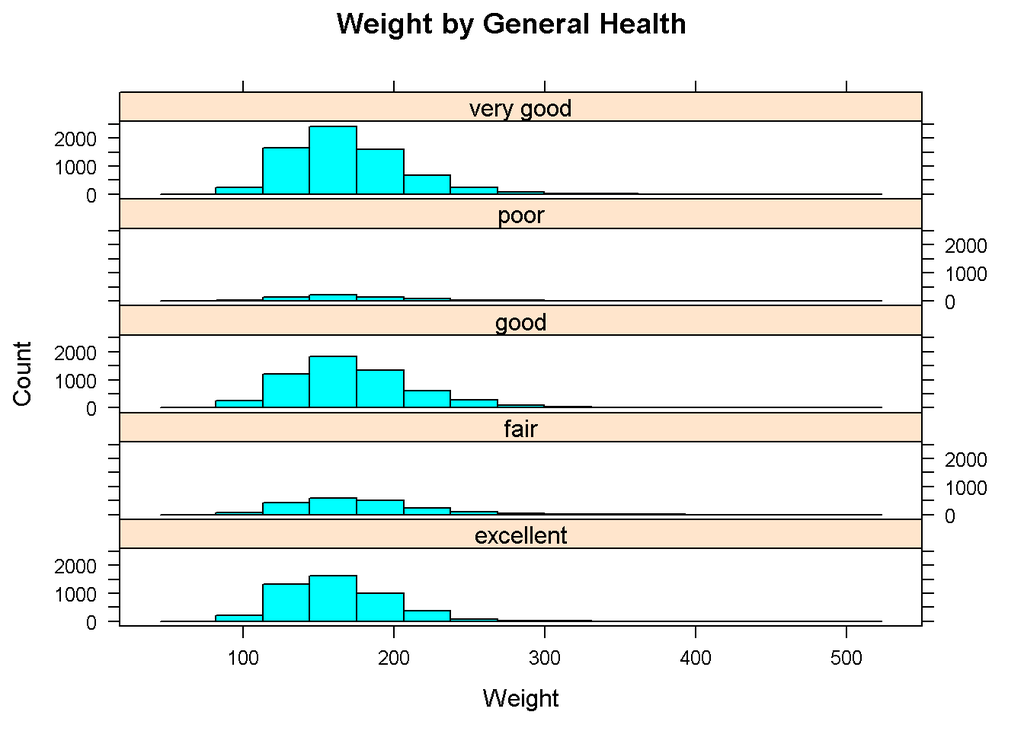

```r
histogram(~health$weight | health$genhlth, type = "count",
          main = "Weight by General Health",
          xlab = "Weight",
          layout = c(1,nlevels(health$genhlth)))
```

For more details on histogram() type ?histogram in the console window below and look at the help window.

### 0.13.1 Now save your file and press the knit button to create your HTML file. I hope you had fun!

```r
Sys.time()
```

```
## [1] "2016-09-08 15:39:34 PDT"
```